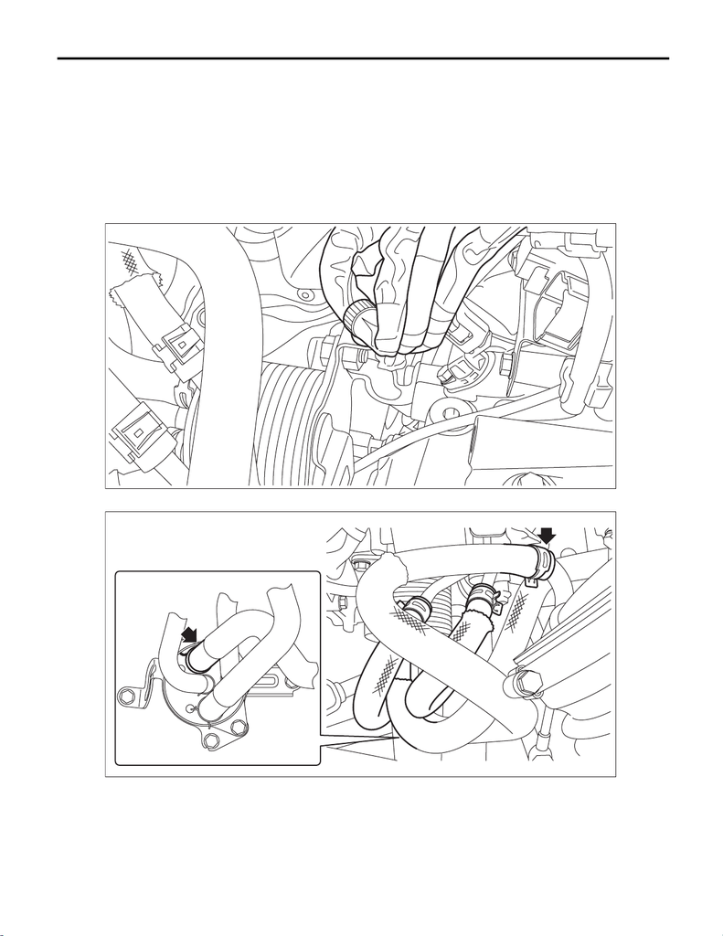

CVT(TR690)-129

CVTF Cooler (With Warmer Function)

CONTINUOUSLY VARIABLE TRANSMISSION

23.CVTF Cooler (With Warmer Function)

A: REMOVAL

CAUTION:

If the CVTF and engine coolant is spilt over exhaust pipe, wipe it off with cloth to avoid emitting

smoke or causing a fire.

1) Disconnect the ground terminal from battery sensor. <Ref. to NT-5, BATTERY, NOTE, Note.>

2) Drain engine coolant. <Ref. to CO(w/o STI)-13, REPLACEMENT, Engine Coolant.>

3) Remove the intercooler. <Ref. to IN(w/o STI)-38, REMOVAL, Intercooler.>

4) Remove the harness clip from the CVTF cooler bracket.

5) Remove the engine coolant outlet hose, engine coolant inlet hose, CVTF inlet hose and CVTF outlet hose.

AT-07731

AT-07827

15WRX_STI_US_EN.book 129 ページ ２０１５年２月１３日 金曜日 午前１１時２０分

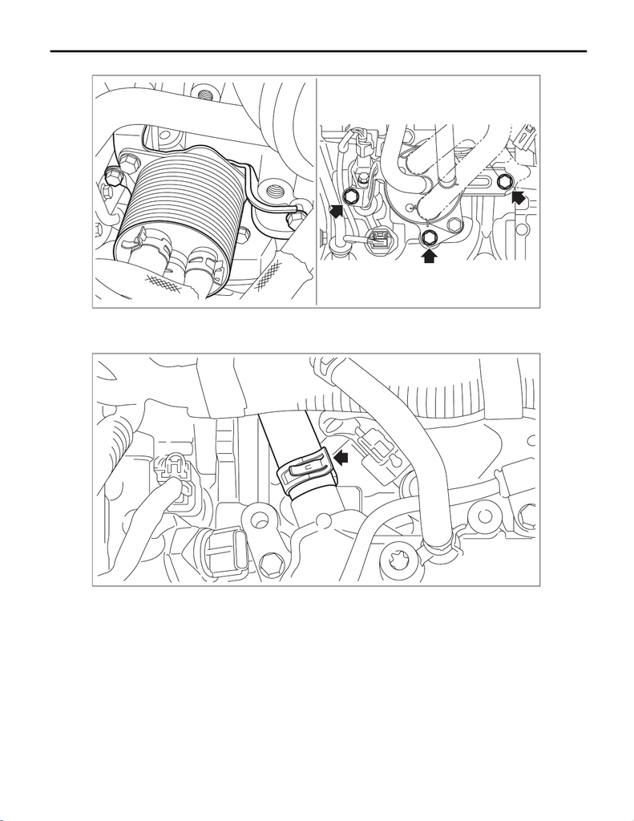

CVT(TR690)-130

CVTF Cooler (With Warmer Function)

CONTINUOUSLY VARIABLE TRANSMISSION

6) Remove the CVTF cooler (with warmer feature) from the transmission.

7) Remove the intake manifold, EGR valve, and the insulator. <Ref. to FU(w/o STI)-18, REMOVAL, Intake

Manifold.> <Ref. to EC(w/o STI)-35, REMOVAL, EGR Control Valve.>

8) Disconnect the engine coolant inlet hose.

AT-07742

AT-07346

15WRX_STI_US_EN.book 130 ページ ２０１５年２月１３日 金曜日 午前１１時２０分

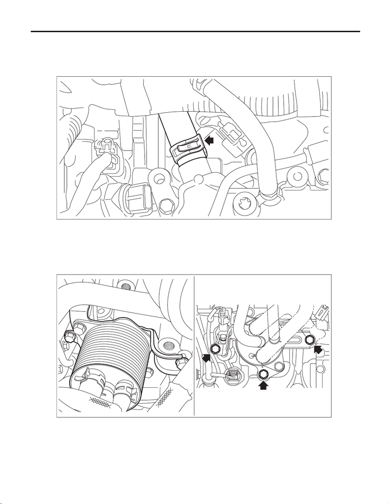

CVT(TR690)-131

CVTF Cooler (With Warmer Function)

CONTINUOUSLY VARIABLE TRANSMISSION

B: INSTALLATION

1) Connect the engine coolant inlet hose.

NOTE:

When installing the engine coolant inlet hose, the triangle marking should face upward.

2) Install the insulator, EGR valve, and the intake manifold. <Ref. to FU(w/o STI)-29, INSTALLATION, Intake

Manifold.> <Ref. to EC(w/o STI)-36, INSTALLATION, EGR Control Valve.>

3) Replace the CVTF inlet hose and the outlet hose.

4) Install the CVTF cooler (with warmer feature) to the transmission.

Tightening torque:

23 N·m (2.3 kgf-m, 17.0 ft-lb)

AT-07346

AT-07742

15WRX_STI_US_EN.book 131 ページ ２０１５年２月１３日 金曜日 午前１１時２０分

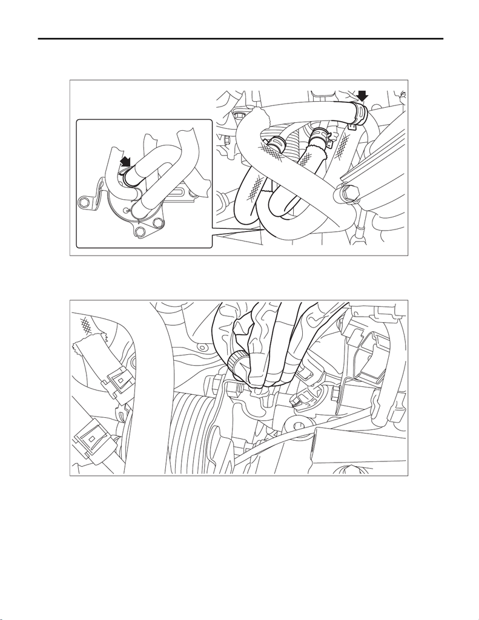

CVT(TR690)-132

CVTF Cooler (With Warmer Function)

CONTINUOUSLY VARIABLE TRANSMISSION

5) Install the engine coolant outlet hose, engine coolant inlet hose, CVTF inlet hose and CVTF outlet hose.

NOTE:

Use new CVTF hoses.

6) Check installation condition of hoses.

• Make sure the hoses do not interfere with each other or with other components.

• Check each hose for bent, excess curve, and twisting conditions.

7) Install the harness clip to the CVTF cooler bracket.

8) Install the intercooler. <Ref. to IN(w/o STI)-41, INSTALLATION, Intercooler.>

9) Connect the ground terminal to battery sensor. <Ref. to NT-5, BATTERY, NOTE, Note.>

10) Fill engine coolant. <Ref. to CO(w/o STI)-13, REPLACEMENT, Engine Coolant.>

11) Adjust the CVTF level. <Ref. to CVT(TR690)-36, ADJUSTMENT, CVTF.>

AT-07827

AT-07731

15WRX_STI_US_EN.book 132 ページ ２０１５年２月１３日 金曜日 午前１１時２０分

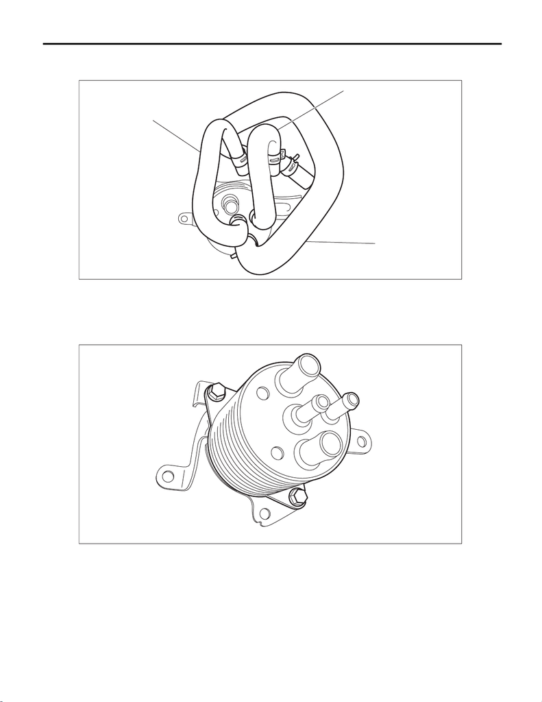

CVT(TR690)-133

CVTF Cooler (With Warmer Function)

CONTINUOUSLY VARIABLE TRANSMISSION

C: DISASSEMBLY

1) Remove the hoses from the CVTF cooler (with warmer feature).

2) Remove the bracket from the CVTF cooler (with warmer feature).

(A) CVTF cooler outlet hose

(B) CVTF cooler inlet hose

(C) Engine coolant outlet hose

AT-07843

(B)

(C)

(A)

AT-07842

15WRX_STI_US_EN.book 133 ページ ２０１５年２月１３日 金曜日 午前１１時２０分

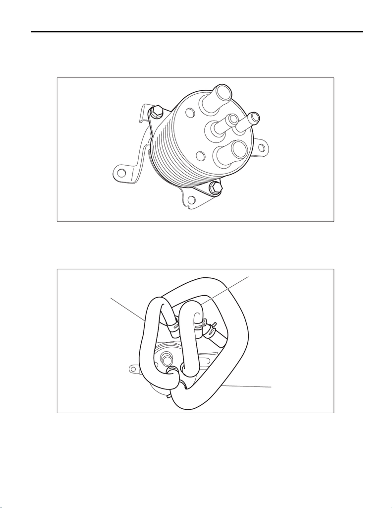

CVT(TR690)-134

CVTF Cooler (With Warmer Function)

CONTINUOUSLY VARIABLE TRANSMISSION

D: ASSEMBLY

1) Attach the bracket.

Tightening torque:

23 N·m (2.3 kgf-m, 17.0 ft-lb)

2) Attach hoses to the CVTF cooler (with warmer feature).

NOTE:

• Use a new CVTF cooler hose.

• Install so that the CVTF cooler hose is not folded over, excessively bent or twisted.

• Insert the CVTF cooler hose to the specified position in the proper direction.

(A) CVTF cooler outlet hose

(B) CVTF cooler inlet hose

(C) Engine coolant outlet hose

AT-07842

AT-07843

(B)

(C)

(A)

15WRX_STI_US_EN.book 134 ページ ２０１５年２月１３日 金曜日 午前１１時２０分

[figure not shown]

CVT(TR690)-135

CVTF Cooler (With Warmer Function)

CONTINUOUSLY VARIABLE TRANSMISSION

E: INSPECTION

Replace any faulty CVTF cooler hoses, CVTF cooler pipes and clamps found in the inspection below.

1) Check that there are no CVTF or engine coolant leaks from the connections.

2) Check the clamp for deformation.

3) Lightly bend the CVTF cooler hose and check for cracks in the surface or other damages.

4) Pinch the CVTF cooler hose with your fingers and check for poor elasticity. Also check for poor elasticity

in the parts where the clamp was installed by pressing with your fingernail.

5) Check for peeling, cracks, and deformation at the tip of the hose.

6) Check the CVTF cooler (with warmer feature) for any damage.

15WRX_STI_US_EN.book 135 ページ ２０１５年２月１３日 金曜日 午前１１時２０分